# Voting rights and the HR2W: Initial analysis and next steps brainstorm

Kristin Dobbin

2023-07-05

### Construction of independent variable of interest

The proposed independent variable of interest to test this question is an ordered factor with four possible options: 1) no governing board; 2) governing board not selected by residents served; 3) board selected by a limited group of residents served (e.g. landowners); and 4) board selected by all registered voters served. The category assigned to each of the 28 institutional types identified in the 2023 institutional update is displayed below. An assignment of “variable” indicates where board selection is variable per California Code. Each of these systems (roughly 90) will be hand coded for the final analysis. Finally, Tribal government institutional types and the unknown private system types are labeled as NA and excluded from consideration in all analyses. The later due to lack of information and the former as outliers due to their unique political structures as sovereign nations.

| 2023 Institution types | Board selection |
| --- | --- |
| California Water District | Variable |
| City | Board selected by residents |
| Community Services District | Board selected by residents |
| County | Board not selected by residents |
| County Sanitation District | Board selected by residents |
| County Service Area | Board not selected by residents |
| County Water District | Board selected by residents |
| County Waterworks District | Board not selected by residents |
| Federal | No board |
| Investor Owned Utility | Board not selected by residents |
| Irrigation District | Variable |
| Joint Powers Authority/Agreement | Variable |
| Maintenance District | Board selected by residents |
| Mobile Home Park | No board |
| Municipal Utility District | Board selected by residents |
| Municipal Water District | Board selected by residents |
| Mutual Benefit | Board selected by limited residents |
| Private - Unknown | NA |
| Private - Ancillary | No board |
| Public Utility District | Board selected by residents |
| Resort Improvement District | Board selected by residents |
| Resource Conservation District | Board selected by residents |
| Sanitary District | Board selected by residents |
| School District | No board |
| Special Act District | Variable |
| State | No board |
| Tribal Government | NA |
| Water Conservation District | Board selected by residents |

#### Questions for feedback: What do you think about this variable and its construction? Is it an accurate and meaningful portrayal of board selection? What changes would you suggest? Would it be better to look at eligibility to serve on the board?

### Proposed outcome variables

System performance can be measured in a variety of ways and there is reason to believe that certain elements of performance may be more influenced by accountability and representation that others. For this reason I propose to use three distinct measures of performance: 1) whether a water system is on California’s failing systems list (binary variable, Y/N); 2) System Needs Assessment risk score (numeric variable, can be disagregated to look at the needs assessment components individually e.g. water quality or affordability); 3) whether the water system applied for COVID-19 arrearage relief on behalf of their customers. These outcome measures are summarized below.

|  | Count | Percent of all systems |
| --- | --- | --- |
| Failing | 338 | 0.12 |
| Not Failing | 2511 | 0.88 |
| NA’s | 11 | 0.00 |

Summary statistics for risk score and components

| Variable | N | Mean | Std. Dev. | Min | Pctl. 25 | Pctl. 75 | Max |
| --- | --- | --- | --- | --- | --- | --- | --- |
| Total_risk | 2688 | 2.3 | 1.5 | 0 | 1.2 | 3.2 | 10 |
| WEIGHTED_WATER_QUALITY_SCORE | 2688 | 0.54 | 0.86 | 0 | 0 | 0.75 | 4.5 |
| WEIGHTED_ACCESSIBILITY_SCORE | 2688 | 0.85 | 0.75 | 0 | 0.33 | 1.3 | 4 |
| WEIGHTED_AFFORDABILITY_SCORE | 2683 | 0.49 | 0.55 | 0 | 0 | 0.67 | 2 |
| WEIGHTED_TMF_CAPACITY_SCORE | 2688 | 0.41 | 0.45 | 0 | 0 | 0.67 | 3.3 |

Summary of arrearage applications

| Variable | N | Percent |
| --- | --- | --- |
| Application.complete. | 2813 |  |
| … No | 1932 | 69% |
| … Yes | 881 | 31% |

#### Questions for feedback: Are there other outcome or performance variables that would be interesting to look at (e.g. total funding received in recent years)? How can we ensure a “well rounded” assessment of water system performance as it relates to the human right to water and best hone in on the influence of governance?

### Proposed controls/covariates

To keep things simple, I’m thinking of using thee controls/covariates in the analyses: 1) population served (log transformed); 2) water source (groundwater or surface water); and 3) whether water is purchased or self-produced.

#### Questions for feedback: Are there other controls that should be considered? How do we think about the role of geography? Is it necessary to include the purchased water variable?

### Exploratory results

I include the following “rough” regressions to help illustrate what this analysis could look like, results will change as the variables and data are finalized.

```
##
## Call:
## glm(formula = CURRENT_FAILING ~ boardselection + LN_POP + Source,
##     family = binomial, data = Data)
##
## Deviance Residuals:
##     Min       1Q   Median       3Q      Max
## -0.7751  -0.5602  -0.4992  -0.3543   2.5363
##
## Coefficients:
##                                                   Estimate Std. Error z value
## (Intercept)                                       -1.19974    0.19556  -6.135
## boardselectionBoard not selected by residents      0.05185    0.22052   0.235
## boardselectionBoard selected by limited residents  0.01453    0.15490   0.094
## boardselectionBoard selected by residents          0.15099    0.18326   0.824
## boardselectionVariable                            -0.29777    0.35959  -0.828
## LN_POP                                            -0.12144    0.03288  -3.694
## SourceSW                                          -0.59908    0.17308  -3.461
##                                                   Pr(>|z|)
## (Intercept)                                       8.52e-10 ***
## boardselectionBoard not selected by residents     0.814121
## boardselectionBoard selected by limited residents 0.925283
## boardselectionBoard selected by residents         0.409981
## boardselectionVariable                            0.407614
## LN_POP                                            0.000221 ***
## SourceSW                                          0.000537 ***
## ---
## Signif. codes:  0 '***' 0.001 '**' 0.01 '*' 0.05 '.' 0.1 ' ' 1
##
## (Dispersion parameter for binomial family taken to be 1)
##
##     Null deviance: 1984.7  on 2760  degrees of freedom
## Residual deviance: 1937.8  on 2754  degrees of freedom
##   (99 observations deleted due to missingness)
## AIC: 1951.8
##
## Number of Fisher Scoring iterations: 5
```

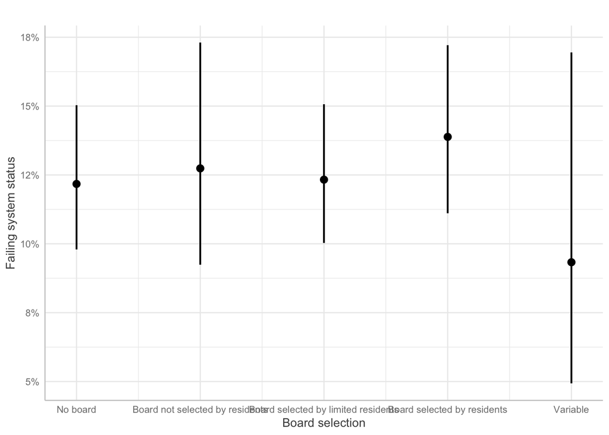

```
##
## Call:
## lm(formula = Total_risk ~ boardselection + LN_POP + Source, data = Data)
##
## Residuals:
##     Min      1Q  Median      3Q     Max
## -2.8614 -1.0073 -0.2713  0.7534  7.3770
##
## Coefficients:
##                                                   Estimate Std. Error t value
## (Intercept)                                        3.99175    0.10098  39.532
## boardselectionBoard not selected by residents     -0.10540    0.10044  -1.049
## boardselectionBoard selected by limited residents -0.48620    0.07363  -6.603
## boardselectionBoard selected by residents          0.03656    0.08808   0.415
## boardselectionVariable                            -0.36074    0.15606  -2.311
## LN_POP                                            -0.23767    0.01712 -13.879
## SourceSW                                          -0.28194    0.07093  -3.975
##                                                   Pr(>|t|)
## (Intercept)                                        < 2e-16 ***
## boardselectionBoard not selected by residents       0.2941
## boardselectionBoard selected by limited residents 4.85e-11 ***
## boardselectionBoard selected by residents           0.6782
## boardselectionVariable                              0.0209 *
## LN_POP                                             < 2e-16 ***
## SourceSW                                          7.23e-05 ***
## ---
## Signif. codes:  0 '***' 0.001 '**' 0.01 '*' 0.05 '.' 0.1 ' ' 1
##
## Residual standard error: 1.397 on 2594 degrees of freedom
##   (259 observations deleted due to missingness)
## Multiple R-squared:  0.134,  Adjusted R-squared:  0.132
## F-statistic: 66.91 on 6 and 2594 DF,  p-value: < 2.2e-16
```

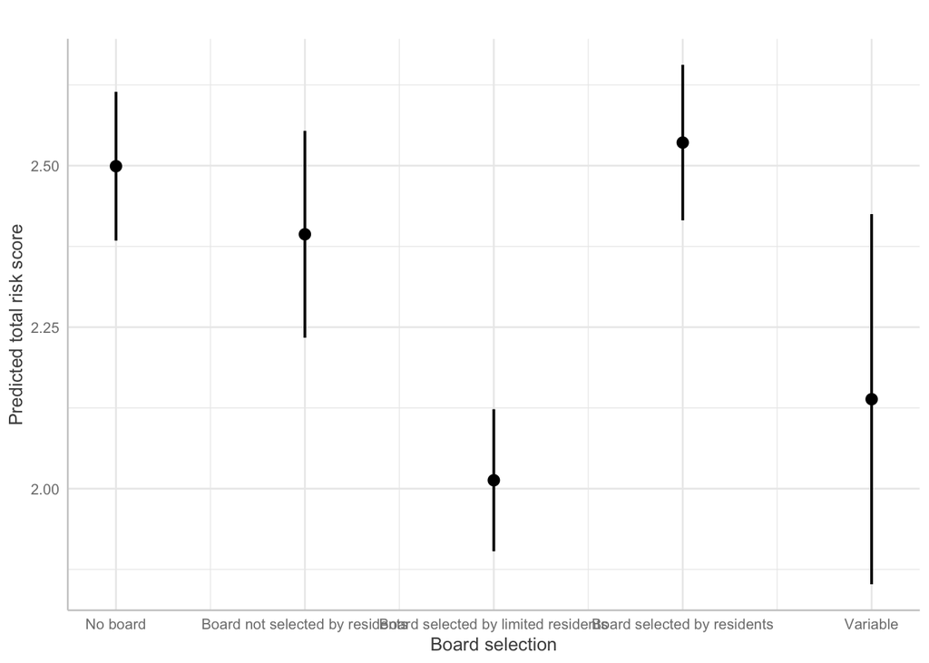

```
##
## Call:
## glm(formula = Application.complete. ~ voting3 + LN_POP + Source,
##     family = binomial, data = Data)
##
## Deviance Residuals:
##     Min       1Q   Median       3Q      Max
## -2.3615  -0.5944  -0.3928   0.5811   2.8168
##
## Coefficients:
##                 Estimate Std. Error z value Pr(>|z|)
## (Intercept)     -3.83225    0.21655 -17.697  < 2e-16 ***
## voting3Limited  -1.13563    0.13986  -8.120 4.67e-16 ***
## voting3None     -0.92942    0.12560  -7.400 1.36e-13 ***
## voting3Variable -0.23711    0.29440  -0.805    0.421
## LN_POP           0.53234    0.02802  18.996  < 2e-16 ***
## SourceSW         0.12131    0.12076   1.005    0.315
## ---
## Signif. codes:  0 '***' 0.001 '**' 0.01 '*' 0.05 '.' 0.1 ' ' 1
##
## (Dispersion parameter for binomial family taken to be 1)
##
##     Null deviance: 3417.9  on 2722  degrees of freedom
## Residual deviance: 2344.7  on 2717  degrees of freedom
##   (137 observations deleted due to missingness)
## AIC: 2356.7
##
## Number of Fisher Scoring iterations: 5
```

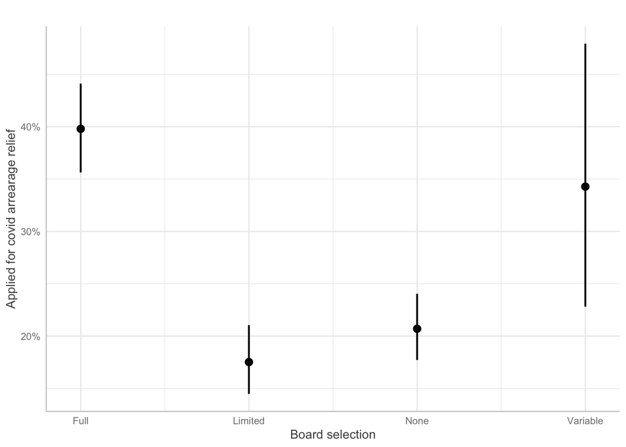